# Italy_Covid-19

ChrisDonoff

16/04/2020

### Import the data

```r
library(dplyr)
italy_import <- read.csv("covid-nationality.csv", header = TRUE)
```

```r
italy_import %>% mutate_if(is.factor, as.character) -> italy_import
italy_import$date <- substr(italy_import$date,1,nchar(italy_import$date)-9)
italy_import %>% mutate_if(is.character, as.factor) -> italy_import
head(italy_import)
```

```
##   X       date state hospitalized_with_symptoms intensive_care
## 1 0 2020-02-24   ITA                        101             26
## 2 1 2020-02-25   ITA                        114             35
## 3 2 2020-02-26   ITA                        128             36
## 4 3 2020-02-27   ITA                        248             56
## 5 4 2020-02-28   ITA                        345             64
## 6 5 2020-02-29   ITA                        401            105
##   total_hospitalized home_quarantine total_confirmed_cases
## 1                127              94                   221
## 2                150             162                   311
## 3                164             221                   385
## 4                304             284                   588
## 5                409             412                   821
## 6                506             543                  1049
##   variation_total_confirmed new_confirmed_cases recovered deaths total_cases
## 1                         0                 221         1      7         229
## 2                        90                  93         1     10         322
## 3                        74                  78         3     12         400
## 4                       203                 250        45     17         650
## 5                       233                 238        46     21         888
## 6                       228                 240        50     29        1128
##   swabs_made casi_testati note_it note_en
## 1       4324           NA
## 2       8623           NA
## 3       9587           NA
## 4      12014           NA
## 5      15695           NA
## 6      18661           NA
```

### Analysis without taking testing into account:

```r
library(astsa)

italy_ts <- italy_import[c(2,10)]

italy_ts %>% mutate(date = as.POSIXct(date)) %>% filter(date < as.POSIXct("2020-02-24"))
```

```
## [1] date                new_confirmed_cases
## <0 rows> (or 0-length row.names)
```

```r
italy_ts$date = as.POSIXct(italy_ts$date)
```

Visualizing the data:

```r
require(timelineR)
```

```
## INFO [2020-04-25 10:30:27] date has been selected as the timestamp column
## INFO [2020-04-25 10:30:27] new_confirmed_cases has been selected as the numeric column(s)
## INFO [2020-04-25 10:30:27]  has been selected as the state column(s)
## INFO [2020-04-25 10:30:27] creating sample plot layers
```

```
## Aligning plots
```

```
## Plotting
```

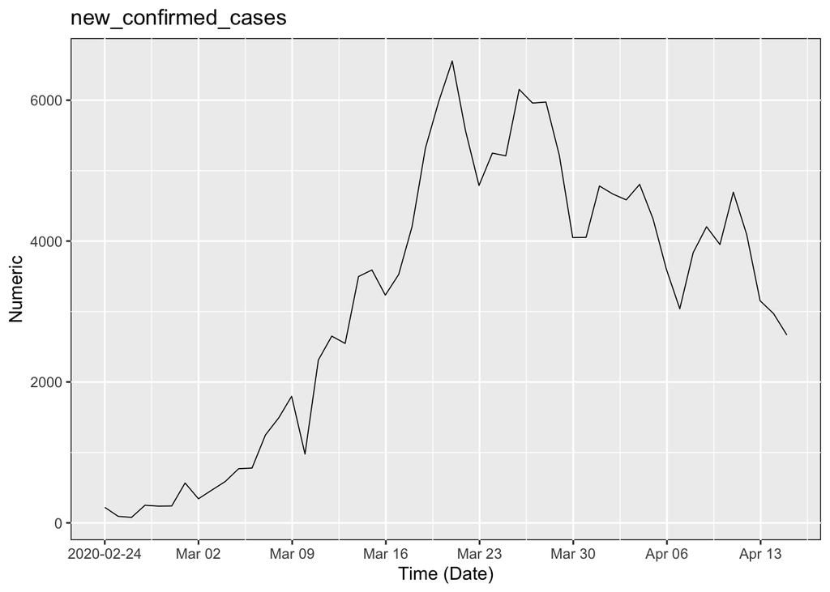

```r
plot_grob <- plot_timeline(italy_ts)
```

Now check if time series is stationary (real data often is not):

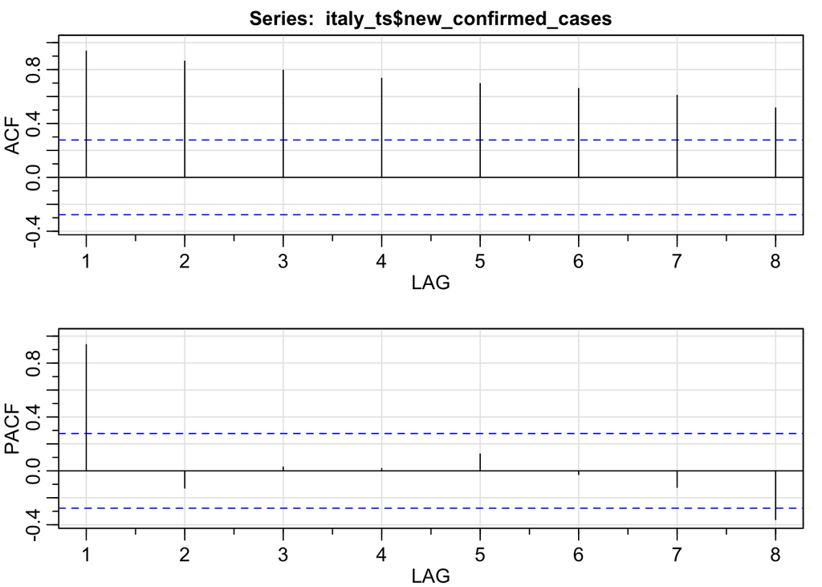

```
##       ACF  PACF
## [1,] 0.94  0.94
## [2,] 0.86 -0.13
## [3,] 0.79  0.03
## [4,] 0.74  0.02
## [5,] 0.70  0.13
## [6,] 0.66 -0.03
## [7,] 0.61 -0.12
## [8,] 0.52 -0.36
```

```r
acf2(italy_ts$new_confirmed_cases)
```

These results indeed confirm that there are autocorrelations and this data is non-stationary, which is as expected.

We now transform this data to stationary, so we can detect potential factors that regression lines would otherwise miss:

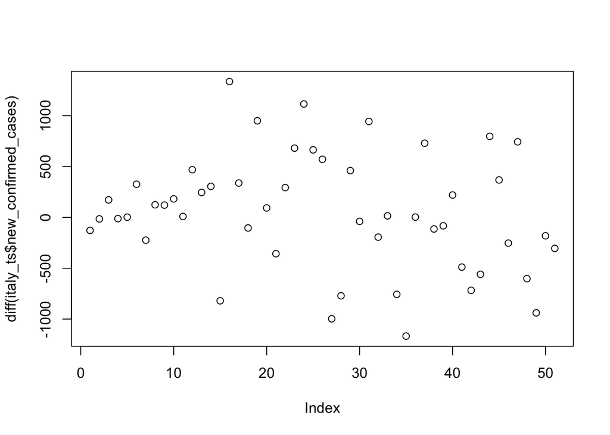

```r
plot(diff(italy_ts$new_confirmed_cases))
```

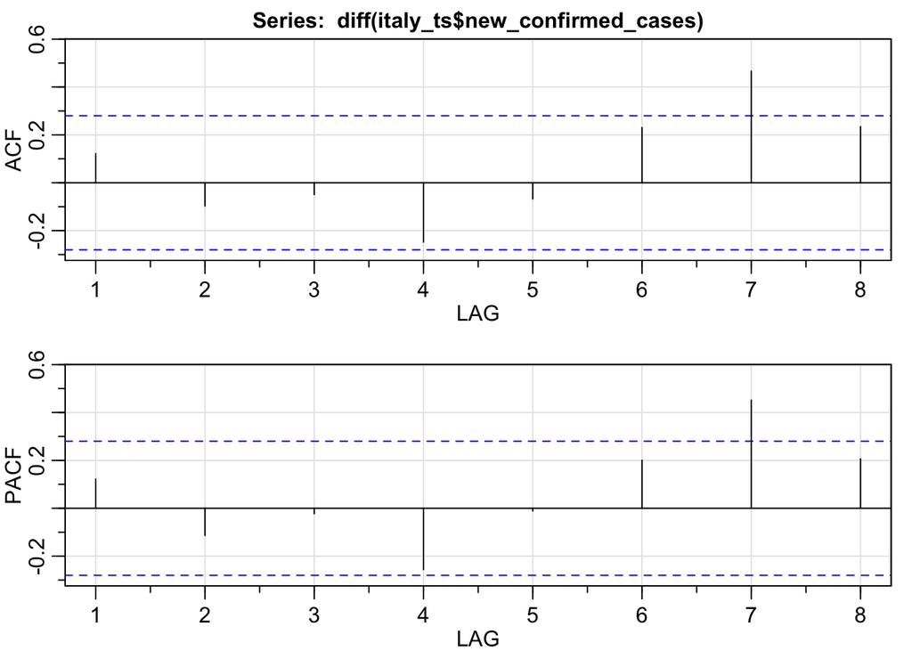

```
##        ACF  PACF
## [1,]  0.12  0.12
## [2,] -0.10 -0.11
## [3,] -0.05 -0.02
## [4,] -0.25 -0.26
## [5,] -0.07 -0.01
## [6,]  0.23  0.20
## [7,]  0.47  0.45
## [8,]  0.23  0.21
```

```r
acf2(diff(italy_ts$new_confirmed_cases))
```

We now fit a time series model using the arima function which takes in 3 parameters (p,d,q), which correspond to the Auto-Regressive order, degree of differencing, and Moving-Average order.

```r
library(forecast)
nobs <- length(italy_ts$new_confirmed_cases)
italy_ar <- arima(diff(italy_ts$new_confirmed_cases), order = c(7,1,0))
italy_pred <- predict(italy_ar, n.ahead=20)
start <- 2667

next_20_diff <- italy_pred$pred

next_20 <- data.frame()

for (i in seq(1:20)){
  start <- start + next_20_diff[i]
  next_20[i,1] <- start
}
```

```r
new_dates <- c()
s_date <- 15
for (i in seq(15)){
  new_dates[i] <- paste('2020-04-', as.character(s_date + 1), sep = "")
  s_date <- s_date + 1
}
new_dates[16] <- '2020-05-01'
new_dates[17] <- '2020-05-02'
new_dates[18] <- '2020-05-03'
new_dates[19] <- '2020-05-04'
new_dates[20] <- '2020-05-05'

predicted <- data.frame(new_dates, next_20)
names(predicted) <- c('date', 'new_confirmed_cases')

italy_predicted <- rbind(italy_ts, predicted)
```

```
## INFO [2020-04-25 10:30:29] date has been selected as the timestamp column
## INFO [2020-04-25 10:30:29] new_confirmed_cases has been selected as the numeric column(s)
## INFO [2020-04-25 10:30:29]  has been selected as the state column(s)
## INFO [2020-04-25 10:30:29] creating sample plot layers
```

```
## Aligning plots
```

```
## Plotting
```

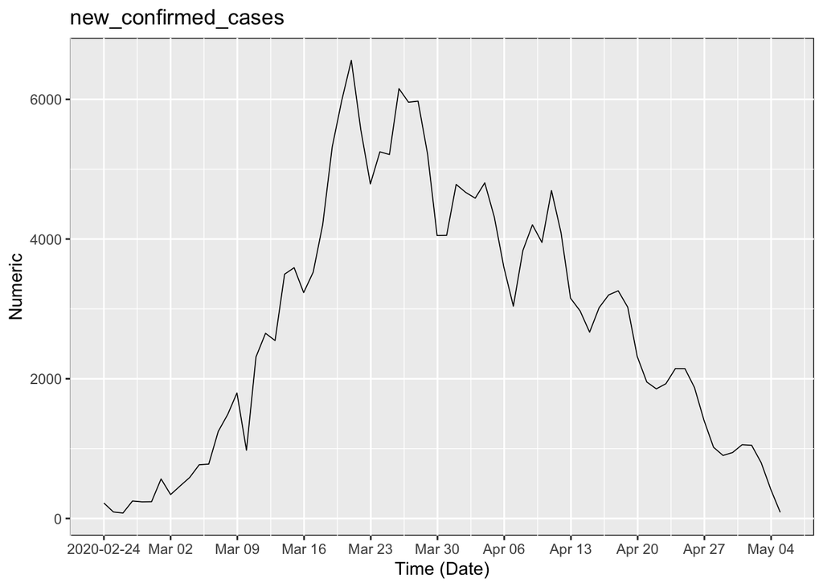

```r
plot_grob <- plot_timeline(italy_predicted)
```

The number of new confrimed cases per day will return back to reasonable numbers in 20 days (May 5th).

### Analysis taking testing into account:

To account for sampling bias, we will control for the number of tests performed by creatig a scaled measure of new cases. This is done by dividing the no. of new confirmed cases by the no. of swabs made. This ratio will more accurately depict the severity of spread in Covid-19, assuming the tests are sufficiently sensitive.

```
## INFO [2020-04-25 10:30:30] date has been selected as the timestamp column
## INFO [2020-04-25 10:30:30] new_confirmed_cases has been selected as the numeric column(s)
## INFO [2020-04-25 10:30:30]  has been selected as the state column(s)
## INFO [2020-04-25 10:30:30] creating sample plot layers
```

```
## Aligning plots
```

```
## Plotting
```

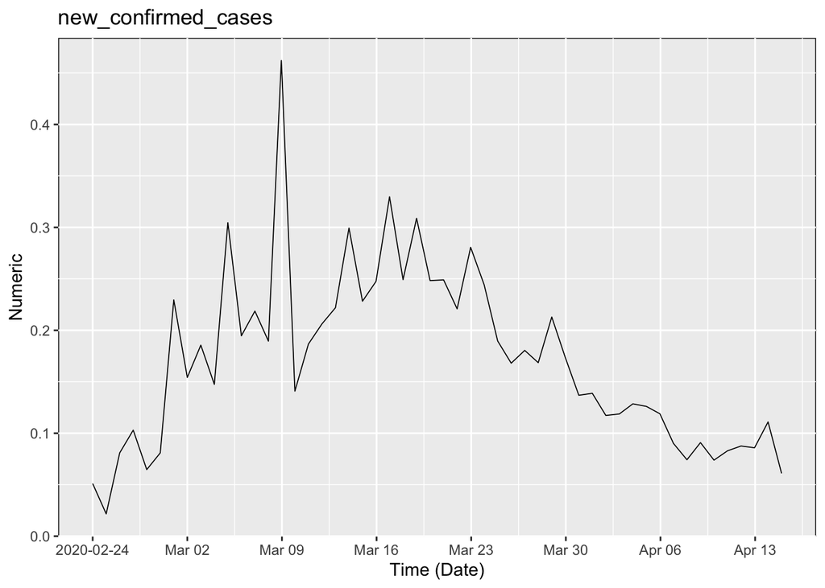

```r
italy_scaled <- italy_ts
italy_scaled$new_confirmed_cases <- italy_ts$new_confirmed_cases/c(4324,diff(unlist(italy_import[14])))


plot_grob <- plot_timeline(italy_scaled)
```

Interestingly, when we account for the number of tests performed, the proportion of new cases scaled by number of tests done has already returned to a rather reasonable level, indicating that the lockdown response was effective.